# visualization

Letian Lin

2025-01-16

## 相关性矩阵

```r
library(corrplot)
library(ggplot2)
library(dplyr)
library(gridExtra)
library("GGally")
library(tidyr)
```

```r
data_railway <- read.csv("2020-11-15成渝高铁上行成都局1车在前3号弓_All.csv")
data_railway1 <- data_railway
Sys.setlocale("LC_CTYPE", "en_US.UTF-8")
```

```
## [1] "en_US.UTF-8"
```

```r
km298 <- data_railway[1562:5579,]
km150 <- data_railway[596224:600252,]
km160 <- data_railway[556037:560072,]
```

- 整公里数 -> WKm 采样点 -> Samp
- 压力1 -> P1, 压力2 -> P2, 压力3 -> P3, 压力4 -> P4
- 垂加基 -> VAB, 横加基 -> LAB
- 温度 -> Temp
- 垂加 -> VA, 垂加1 -> VA1, 垂加2 -> VA2, 垂加3 -> VA3, 垂加4 -> VA4
- 滑板1压力 -> S1P, 滑板2压力 -> S2P
- 无补偿接触力 -> UC, 有补偿接触力 -> CC, 空气动力补偿接触力 -> ACC
- 硬点 -> HP
- 冲击 -> Imp
- 接触拉出值 -> CDV, 接触导高 -> CH
- 网流 -> NC
- 网压 -> NV
- 纵加 -> LA, 纵加1 -> LA1, 纵加2 -> LA2, 纵加3 -> LA3, 纵加4 -> LA4
- 火花次数 -> SC, 火花时间 -> SD
- 保留1 -> R1, 保留2 -> R2, 保留3 -> R3, 保留4 -> R4
- 速度 -> Sp
- 公里标 -> MM
- 支柱 -> Sup
- 非接触导高1 -> NCH1, 非接触导高2 -> NCH2
- 非接触拉出值1 -> NCDV1, 非接触拉出值2 -> NCDV2
- 非接触磨耗1 -> NCW1, 非接触磨耗2 -> NCW2
- 接触线坡度 -> CWG
- 吊悬 -> Sus
- 功率 -> Pow

```r
# 替换列名
colnames(data_railway) <- c(
  "WKm", "Samp", "P1", "P2", "P3", "P4",
  "VAB", "LAB", "Temp", "VA",
  "VA1", "VA2", "VA3", "VA4",
  "S1P", "S2P", "UC", "CC",
  "ACC", "HP", "Imp", "CDV", "CH",
  "NC", "NV", "LA", "LA1",
  "LA2", "LA3", "LA4", "SC",
  "SD", "R1", "R2", "R3", "R4", "Sp", "MM",
  "Sup", "NCH1", "NCH2", "NCDV1",
  "NCDV2", "NCW1", "NCW2", "CWG",
  "Sus", "Pow"
)
cor_matrix <- cor(data_railway)  # 计算相关系数矩阵
```

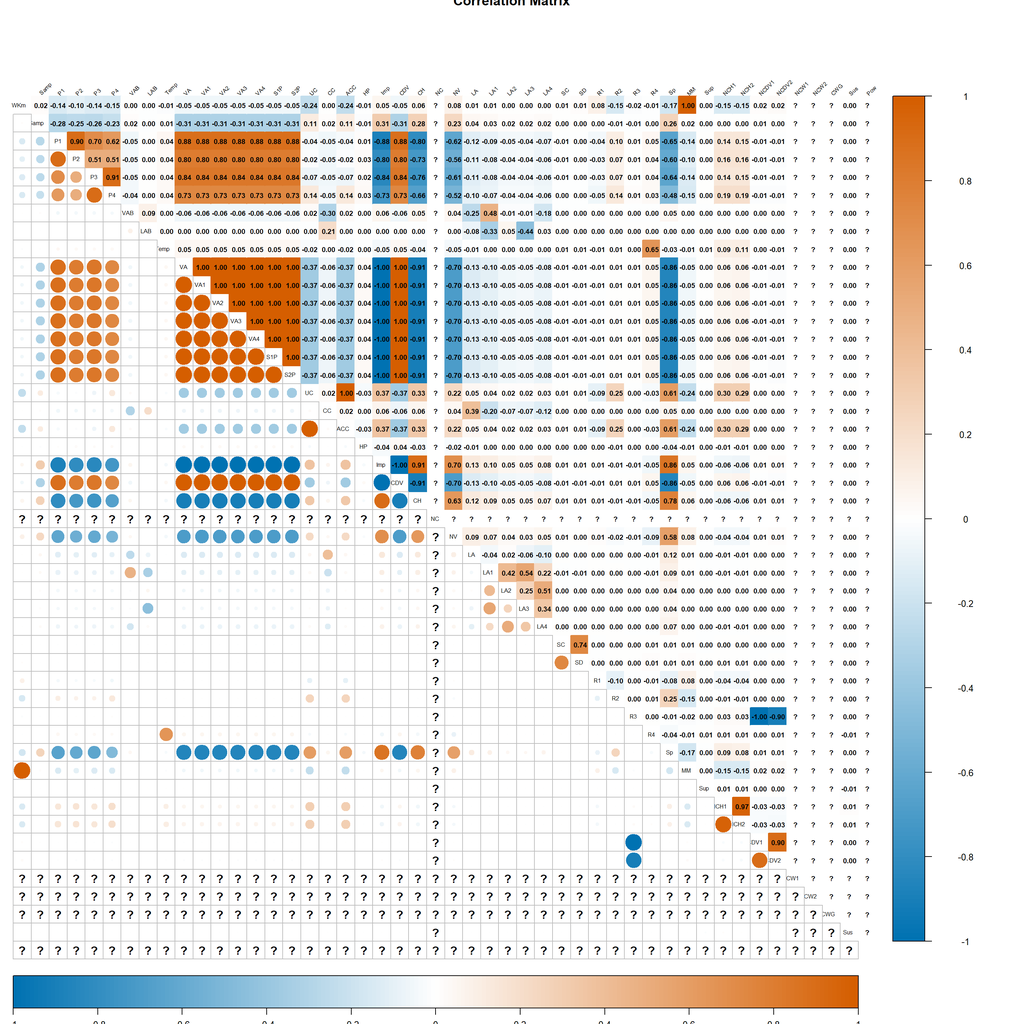

```r
options(repr.plot.width = 15, repr.plot.height = 15)  # 调整画布尺寸

# 自定义相关矩阵绘图
corrplot(
  cor_matrix,
  method = "color",                     # 上三角区域使用颜色填充
  col = colorRampPalette(c("#0072B2", "white", "#D55E00"))(200),
  addCoef.col = "black",                # 显示相关系数
  number.cex = 0.6,                     # 相关系数字体大小
  type = "upper",                       # 上三角显示相关系数
  diag = FALSE,                         # 不显示对角线
  tl.col = "black",                     # 标签颜色
  tl.cex = 0.5,
  tl.srt = 45,                          # 标签字体大小
  cl.cex = 0.8,                         # 图例字体大小
  title = "Correlation Matrix",         # 图表标题

)

# 下三角显示圆圈
corrplot(
  cor_matrix,
  method = "circle",                    # 下三角区域使用圆圈
  col = colorRampPalette(c("#0072B2", "white", "#D55E00"))(200),
  type = "lower",                       # 下三角显示圆圈
  add = TRUE,                           # 叠加图表
  diag = FALSE,                         # 不显示对角线
  tl.pos = "n",                         # 隐藏下三角的标签
  cl.pos = "b",                         # 图例位置（底部）
  cl.cex = 0.8                          # 图例字体大小
)
```

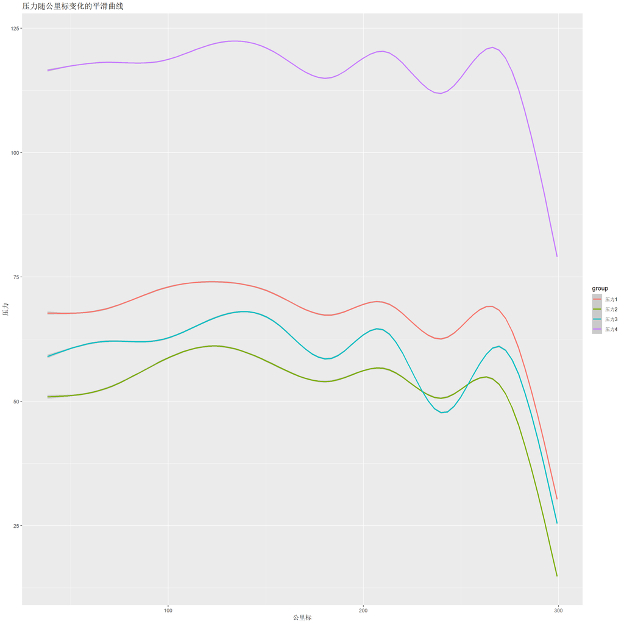

```r
data_railway <- read.csv("2020-11-15成渝高铁上行成都局1车在前3号弓_All.csv")
df_long <- pivot_longer(data_railway1, cols = c("压力1","压力2","压力3","压力4"), names_to = "group", values_to = "value")
ggplot(df_long, aes(x = 公里标, y = value, colour = group)) +
  geom_smooth()+
  labs(title = "压力随公里标变化的平滑曲线", x = "公里标", y = "压力")
```

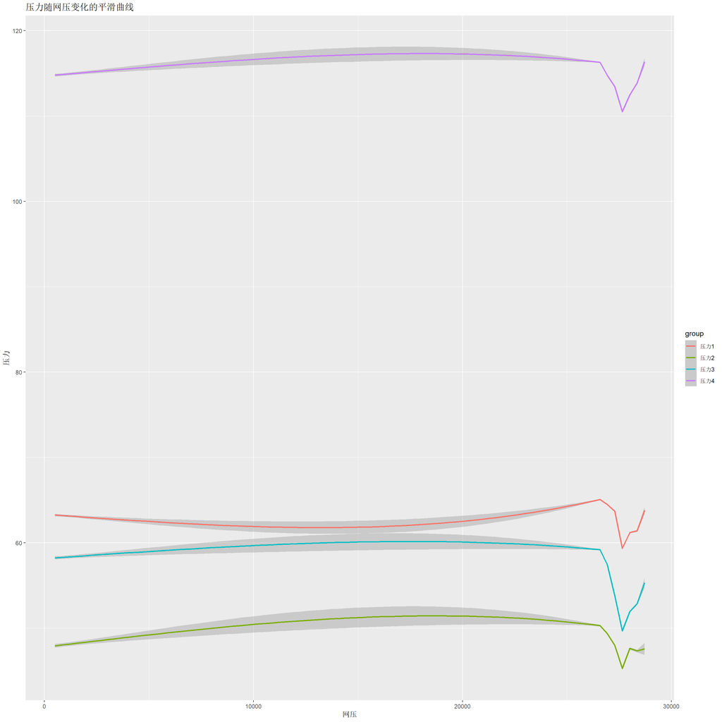

```r
ggplot(subset(df_long, 网压 != 0), aes(x = 网压, y = value, colour = group)) +
  geom_smooth()+
  labs(title = "压力随网压变化的平滑曲线", x = "网压", y = "压力")
```

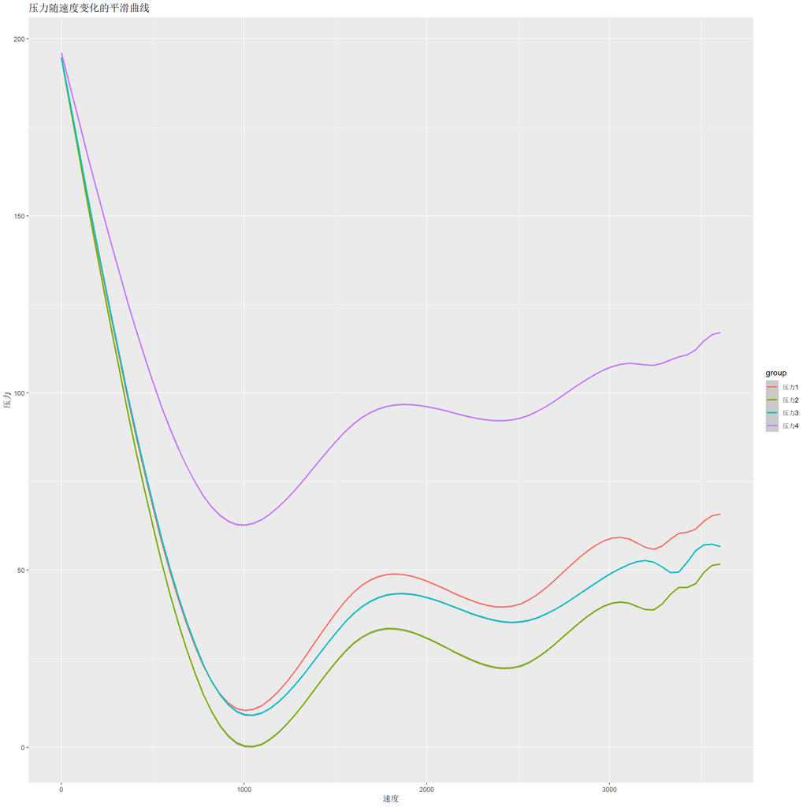

```r
ggplot(subset(df_long, 速度 != 0), aes(x = 速度, y = value, colour = group)) +
  geom_smooth()+
  labs(title = "压力随速度变化的平滑曲线", x = "速度", y = "压力")
```

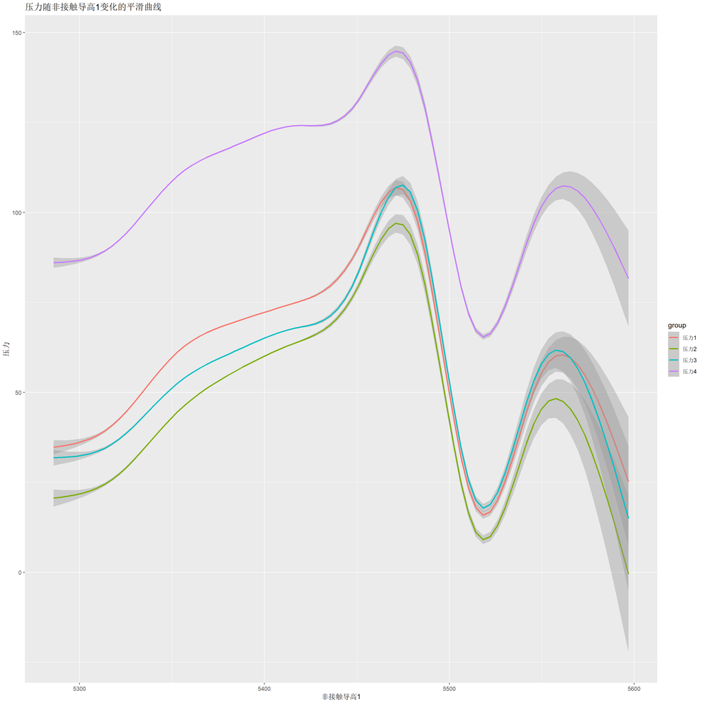

```r
ggplot(subset(df_long, 非接触导高1 != 0), aes(x = 非接触导高1, y = value, colour = group)) +
  geom_smooth()+
  labs(title = "压力随非接触导高1变化的平滑曲线", x = "非接触导高1", y = "压力")
```

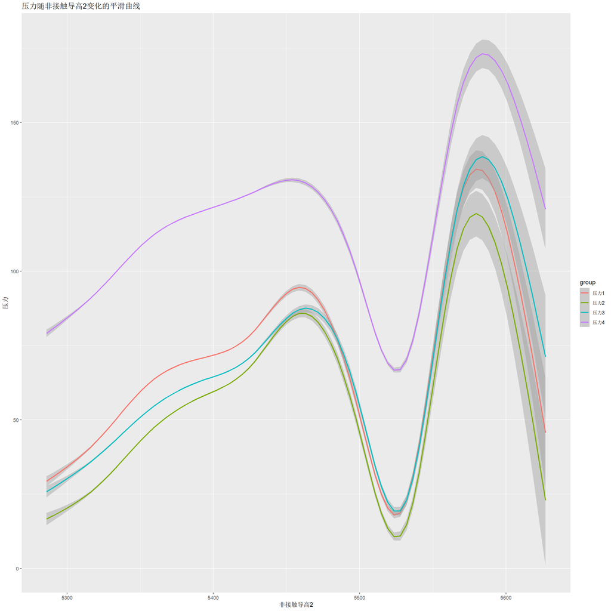

```r
ggplot(subset(df_long, 非接触导高2 != 0), aes(x = 非接触导高2, y = value, colour = group)) +
  geom_smooth()+
  labs(title = "压力随非接触导高2变化的平滑曲线", x = "非接触导高2", y = "压力")
```

# 150km段

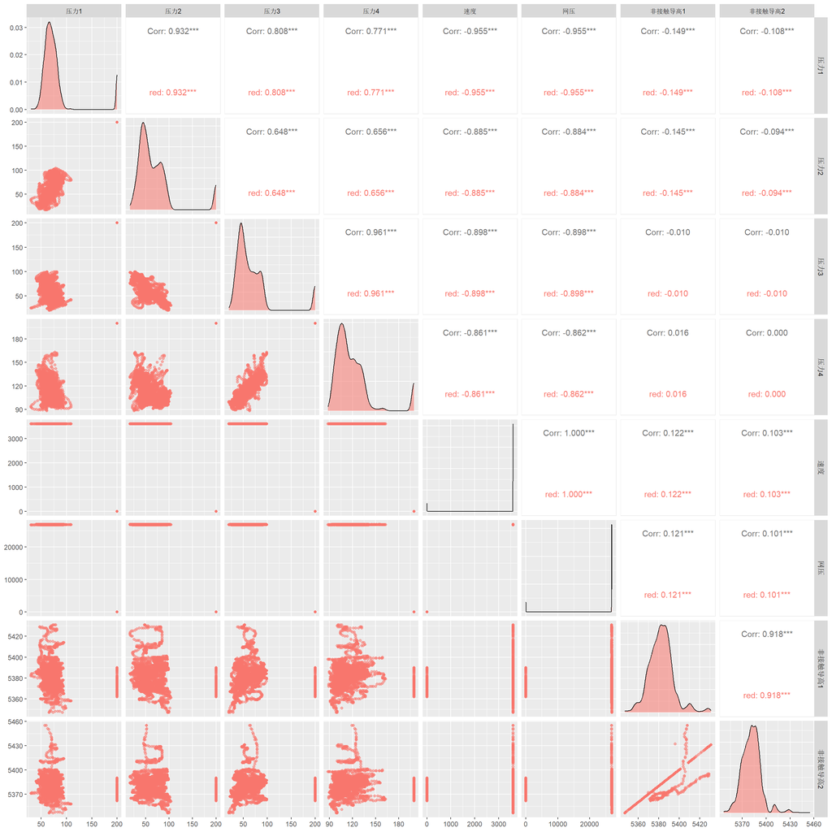

```r
ggpairs(km150[,c("压力1","压力2","压力3","压力4","速度","网压","非接触导高1","非接触导高2")], aes(colour = "red", alpha = 0.4))
```

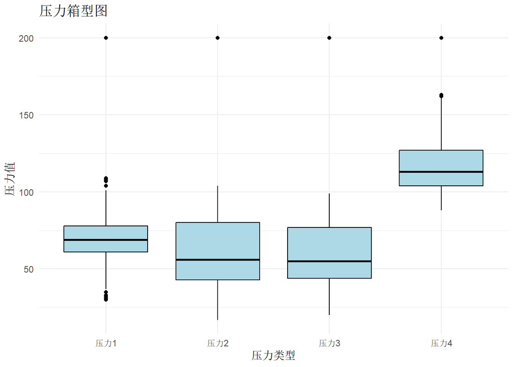

```r
data_box <- pivot_longer(km150,cols = c("压力1","压力2","压力3","压力4"), names_to = "压力类型", values_to = "压力值")
ggplot(data_box, aes(x = 压力类型, y = 压力值)) +
  geom_boxplot(fill = "lightblue", color = "black") +
  labs(title = "压力箱型图", x = "压力类型", y = "压力值") +
  theme_minimal()
```

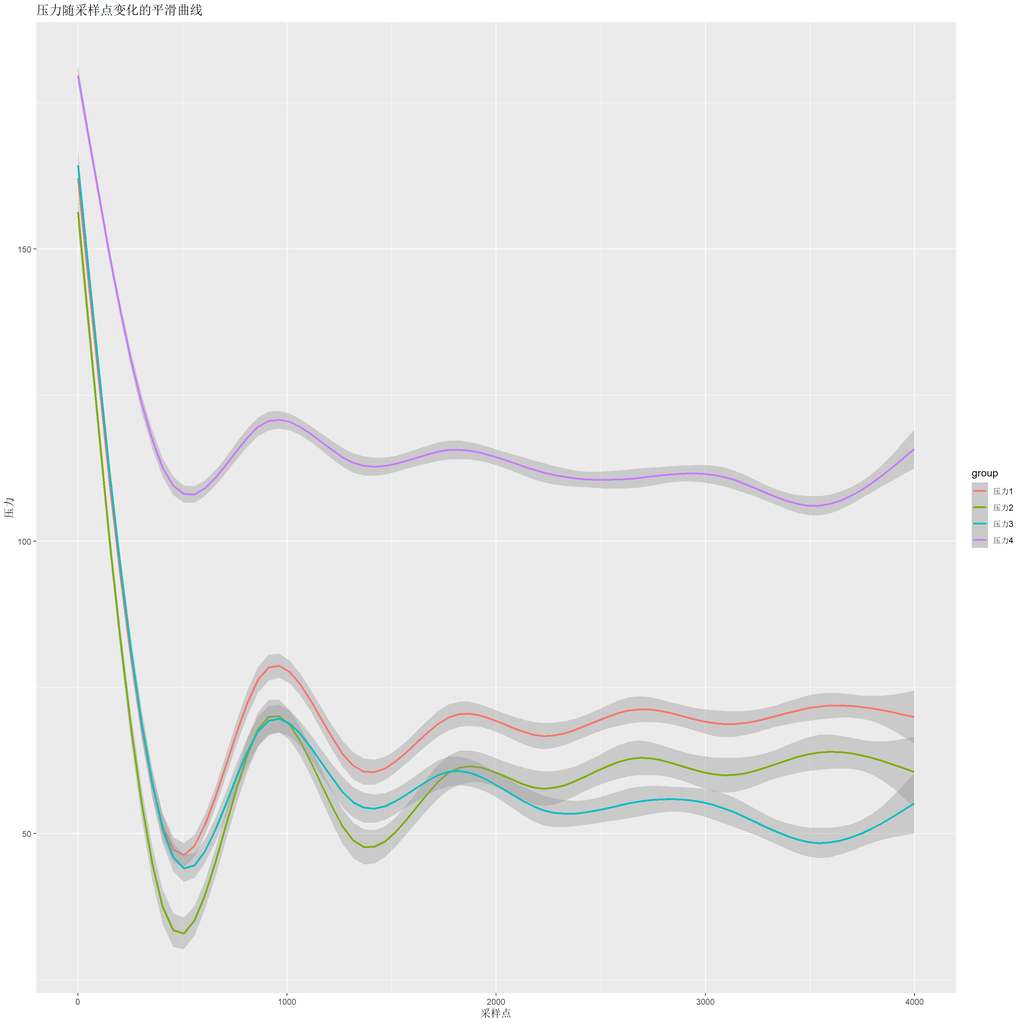

```r
df_long150 <- pivot_longer(km150, cols = c("压力1","压力2","压力3","压力4"), names_to = "group", values_to = "value")
ggplot(subset(df_long150, 公里标 != 0), aes(x = 采样点, y = value, colour = group))+
  geom_smooth()+
  labs(title = "压力随采样点变化的平滑曲线", x = "采样点", y = "压力")
```

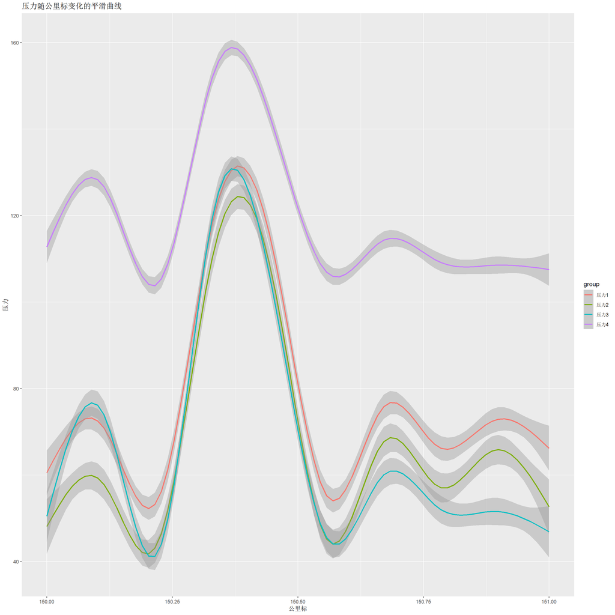

```r
df_long150 <- pivot_longer(km150, cols = c("压力1","压力2","压力3","压力4"), names_to = "group", values_to = "value")
ggplot(subset(df_long150, 公里标 != 0), aes(x = 公里标, y = value, colour = group))+
  geom_smooth()+
  labs(title = "压力随公里标变化的平滑曲线", x = "公里标", y = "压力")
```

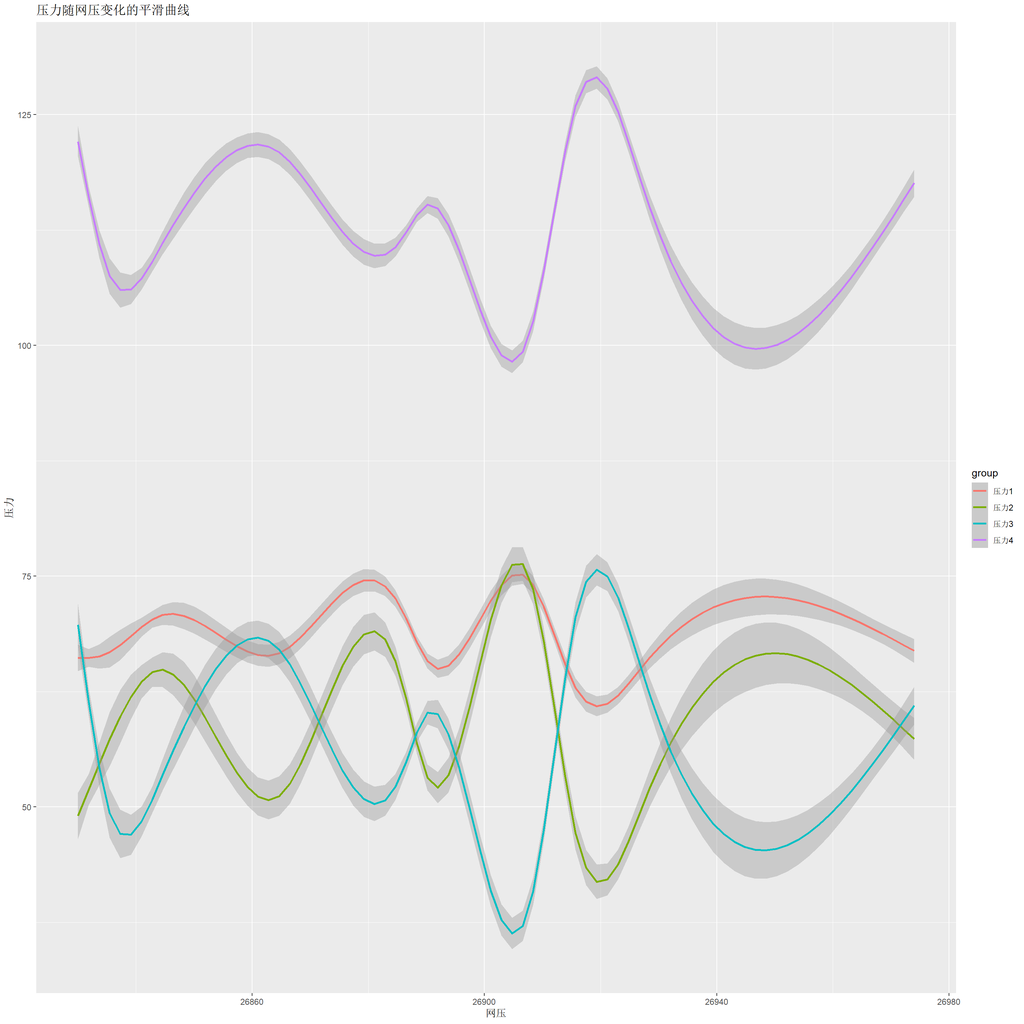

```r
ggplot(subset(df_long150, 网压 != 0), aes(x = 网压, y = value, colour = group))+
  geom_smooth()+
  labs(title = "压力随网压变化的平滑曲线", x = "网压", y = "压力")
```

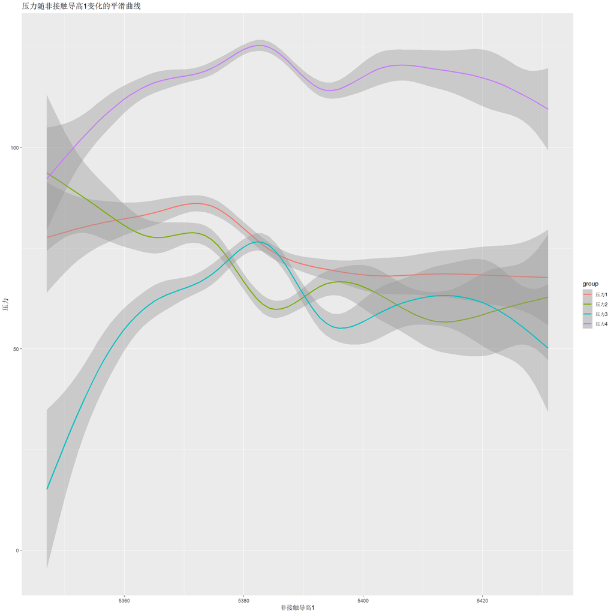

```r
ggplot(subset(df_long150, 非接触导高1 != 0), aes(x = 非接触导高1, y = value, colour = group))+
  geom_smooth()+
  labs(title = "压力随非接触导高1变化的平滑曲线", x = "非接触导高1", y = "压力")
```

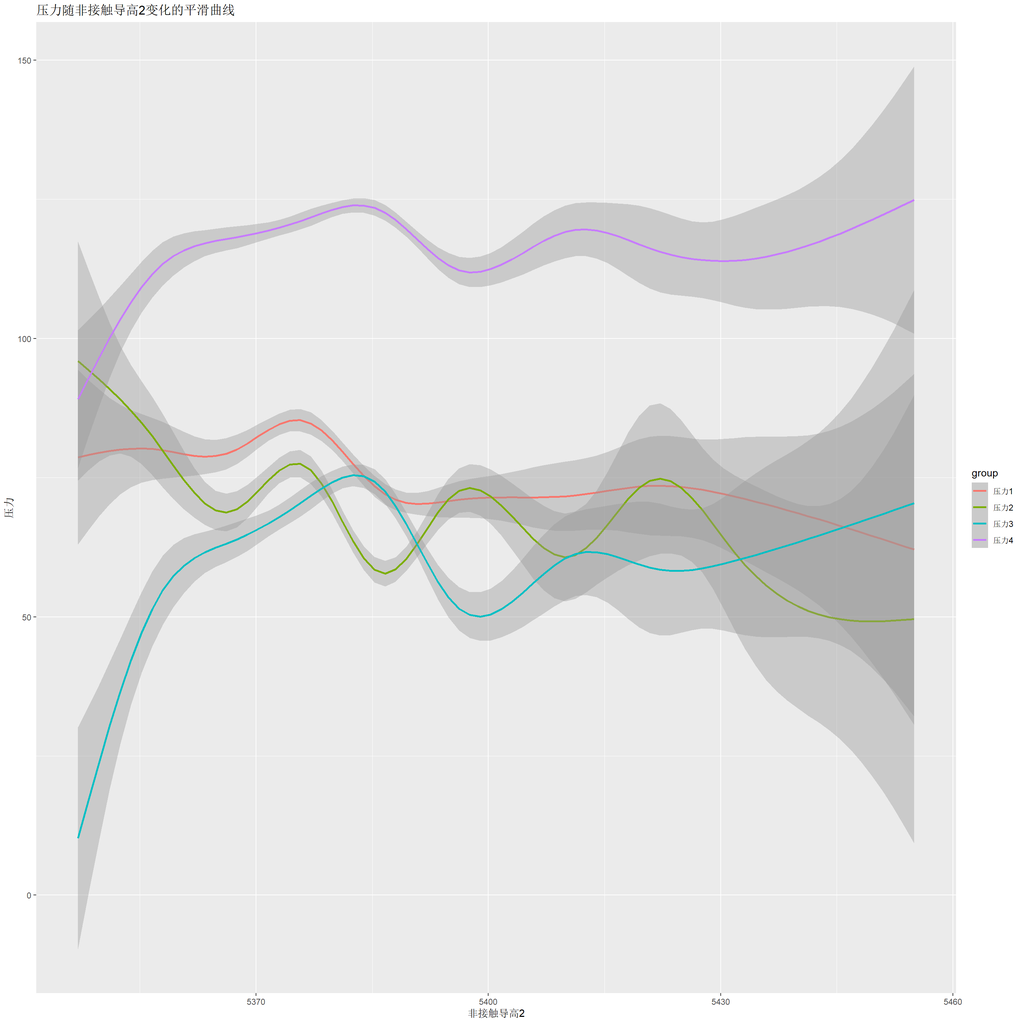

```r
ggplot(subset(df_long150, 非接触导高2 != 0), aes(x = 非接触导高2, y = value, colour = group))+
  geom_smooth()+
  labs(title = "压力随非接触导高2变化的平滑曲线", x = "非接触导高2", y = "压力")
```